# Strategies for improving MCMC

NIMBLE 2020 Virtual Workshop

NIMBLE Development Team

June 2020

# Overview

Some strategies for improving MCMC

- Customize sampler choices. E.g.,
  - Try sampling standard deviations on a log scale [already seen].
  - Try slice samplers instead of Metropolis-Hastings [already seen].
  - Try blocking correlated parameters [already seen; more here]
  - Try multiple samplers for slow-mixing parameters [not shown].
- Reparameterize
  - Center covariates [already seen]
  - Centered versus non-centered random effects
  - Rotated coordinates to reduce posterior correlation [already seen; more here]
- (Advanced) Write new samplers that take advantage of particular model structures [tomorrow]
- Rewrite the model to reduce dependencies
- Vectorize declarations to improve computational efficiency
- Marginalize to remove parameters

# Load the Deer E. cervi example for later:

```r
source(file.path("..", "examples", "DeerEcervi", "load_DeerEcervi.R"),
       chdir = TRUE)
```

# Sampler choices and centering covariates or random effects (1)

Sampler choices:

- Blocking can help when parameters are correlated *given other parameters*.
  - If parameters are *marginally correlated* but *conditionally independent*, blocking will not help.
  - This occurs if parameters are marginally correlated only because they both depend on something else.
- Slice sampling can help mix a parameter at some computational cost.
- Sampling standard deviations on a log scale can help, especially when there is posterior support near 0.
- Model-specific understanding can yield good sampling strategies.

# Sampler choices and centering covariates or random effects (2)

Centering refers to two issues:

- Centering of covariates as they are provided for the analysis.
  - Think of $y_i = \beta_0 + \beta_1 x_i + \epsilon_i$.
  - If the $x_i$ are not centered, then considering $\beta_1 \rightarrow \beta_1'$ is also like adding $(\beta_1' - \beta_1) \bar{x}$ to the intercept.
  - A standard result in linear regression is that estimates of $\beta_0$ and $\beta_1$ are correlated.
  - Centering $x_i$ around its mean removes the posterior correlation between $\beta_0$ and $\beta_1$.
  - In our example, we centered `Length`, but not separately for each sex.
- Random effects with a mean of zero (non-centered) versus centered around a mean.
  - E.g., `farm.effect ~ N(0, sd)` vs. `farm.effect ~ N(mu, sd)`.
  - Theory shows either parameterization can be better, depending on the model and data, but with reasonable amount of data, centered is often better.

# Back to the E. cervi MCMC

Let’s take a deeper look at the mixing of our basic MCMC for the E. cervi example with the ‘length’ variable centered.

```r
set.seed(123)
model <- nimbleModel(DEcode1 , constants = DEconstants, inits = DEinits_vals, data = DEdata)
```

```
## defining model...
```

```
## building model...
```

```
## setting data and initial values...
```

```
## running calculate on model (any error reports that follow may simply reflect missing values in model variables) ...
## checking model sizes and dimensions...
## model building finished.
```

```r
cmodel <- compileNimble(model)
```

```
## compiling... this may take a minute. Use 'showCompilerOutput = TRUE' to see C++ compilation details.
## compilation finished.
```

```r
mcmcConf <- configureMCMC(model)
```

```
## ===== Monitors =====
## thin = 1: sex.effect, length.effect, farm.sd
## ===== Samplers =====
## RW sampler (29)
##   - sex.effect[]  (2 elements)
##   - length.effect[]  (2 elements)
##   - farm.sd
##   - farm.effect[]  (24 elements)
```

```r
mcmcConf$addMonitors('farm.effect')
```

```
## thin = 1: sex.effect, length.effect, farm.sd, farm.effect
```

```r
mcmc <- buildMCMC(mcmcConf)
cmcmc <- compileNimble(mcmc, project = model)
```

```
## compiling... this may take a minute. Use 'showCompilerOutput = TRUE' to see C++ compilation details.
## compilation finished.
```

```r
system.time(samplesOrig <- runMCMC(cmcmc, niter = 5000))
```

```
## running chain 1...
```

```
## |-------------|-------------|-------------|-------------|
## |-------------------------------------------------------|
```

```
##    user  system elapsed
##    4.33    0.02    4.35
```

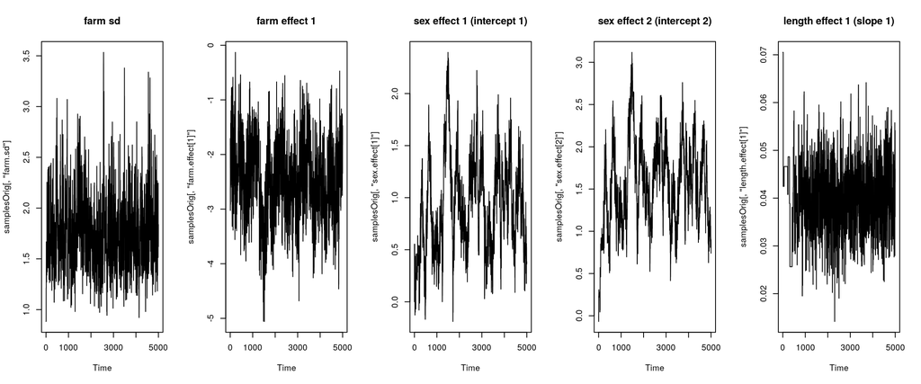

```r
# change to c(3,5) in live demo
par(mfrow = c(1,5))
ts.plot(samplesOrig[ , 'farm.sd'], main = 'farm sd')
ts.plot(samplesOrig[ , 'farm.effect[1]'], main = 'farm effect 1')
ts.plot(samplesOrig[ , 'sex.effect[1]'], main = 'sex effect 1 (intercept 1)')
ts.plot(samplesOrig[ , 'sex.effect[2]'], main = 'sex effect 2 (intercept 2)')
ts.plot(samplesOrig[ , 'length.effect[1]'], main = 'length effect 1 (slope 1)')
```

What’s not mixing? The intercepts (sex.effects) go up and down together and the farm effects inversely to them.

Why?

```
  logit(disease.probability[i]) <-
      sex.effect[ sex[i] ] +
      length.effect[ sex[i] ]*cLength[i] +
      farm.effect[ farm.ids[i] ]
```

# Solution: center the random effects

Solution: center the random effects Difficulty: there are two intercepts! Secondary solution: have second intercept be an offset for sex 2 only

```r
DEcode3 <- nimbleCode({
  sex.effect[2] ~ dnorm(0, sd = 1000)     # offset for sex 2
  sex.effect[1] <- 0                      # replaced by 'mu'
  for(i in 1:2) {
    # Priors for ntercepts and length coefficients for sex = 1,2
    length.effect[i] ~ dnorm(0, sd = 1000)
  }

  # Priors for farm random effects and their standard deviation.
  farm.sd ~ dunif(0, 20)
  for(i in 1:num.farms) {
    farm.effect[i] ~ dnorm(mu, sd = farm.sd)  # centered random effects
  }
  mu ~ dnorm(0, sd = 100)

  # logit link and Bernoulli data probabilities
  for(i in 1:num.animals) {
    logit(disease.probability[i]) <-
      sex.effect[ sex[i] ] +
      length.effect[ sex[i] ]*cLength[i] +
      farm.effect[ farm.ids[i] ]
    Ecervi.01[i] ~ dbern(disease.probability[i])
  }
})

set.seed(123)
model3 = nimbleModel(DEcode3 , constants = DEconstants, inits = c(DEinits_vals, mu = 0), data = DEdata)
```

```
## defining model...
```

```
## building model...
```

```
## setting data and initial values...
```

```
## running calculate on model (any error reports that follow may simply reflect missing values in model variables) ...
## checking model sizes and dimensions...
## model building finished.
```

```r
cmodel3 <- compileNimble(model3)
```

```
## compiling... this may take a minute. Use 'showCompilerOutput = TRUE' to see C++ compilation details.
```

```
## compilation finished.
```

```r
mcmcConf3 <- configureMCMC(model3)
```

```
## ===== Monitors =====
## thin = 1: sex.effect, length.effect, farm.sd, mu
## ===== Samplers =====
## RW sampler (28)
##   - sex.effect[]  (1 element)
##   - length.effect[]  (2 elements)
##   - farm.sd
##   - farm.effect[]  (24 elements)
## conjugate sampler (1)
##   - mu
```

```r
mcmcConf3$addMonitors('farm.effect')
```

```
## thin = 1: sex.effect, length.effect, farm.sd, mu, farm.effect
```

```r
mcmc3 <- buildMCMC(mcmcConf3)
cmcmc3 <- compileNimble(mcmc3, project = model3)
```

```
## compiling... this may take a minute. Use 'showCompilerOutput = TRUE' to see C++ compilation details.
## compilation finished.
```

```r
system.time(samplesCtrRE <- runMCMC(cmcmc3, niter = 5000))
```

```
## running chain 1...
```

```
## |-------------|-------------|-------------|-------------|
## |-------------------------------------------------------|
```

```
##    user  system elapsed
##   3.197   0.012   3.209
```

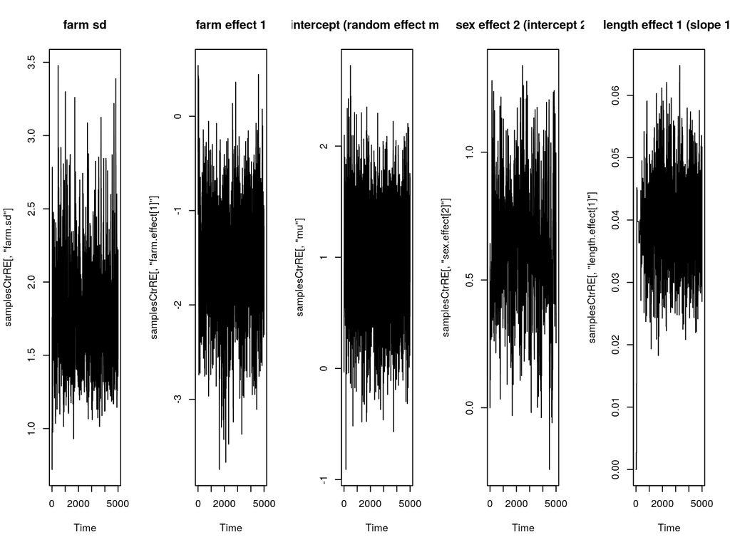

```r
par(mfrow = c(1,5))
ts.plot(samplesCtrRE[ , 'farm.sd'], main = 'farm sd')
ts.plot(samplesCtrRE[ , 'farm.effect[1]'], main = 'farm effect 1')
ts.plot(samplesCtrRE[ , 'mu'], main = 'intercept (random effect mean)')
ts.plot(samplesCtrRE[ , 'sex.effect[2]'], main = 'sex effect 2 (intercept 2)')
ts.plot(samplesCtrRE[ , 'length.effect[1]'], main = 'length effect 1 (slope 1)')
```

So that works pretty well.

# Back to E. cervi, but without centering the covariate

Let’s consider the original model, but without centering the covariate.

```r
DEconstants_uncentered <- DEconstants # Artificially un-center Length
DEconstants_uncentered$cLength <- DeerEcervi$Length # cLength is now mis-named,
                                                    # but it's easier than new model code.

set.seed(123)
DEinits_vals_uncentered <- DEinits_vals
DEinits_vals_uncentered$sex.effect <- c(-8, -8)

model4 = nimbleModel(DEcode1, constants = DEconstants_uncentered, inits = DEinits_vals_uncentered, data = DEdata)
```

```
## defining model...
```

```
## building model...
```

```
## setting data and initial values...
```

```
## running calculate on model (any error reports that follow may simply reflect missing values in model variables) ...
## checking model sizes and dimensions...
## model building finished.
```

```r
cmodel4 <- compileNimble(model4)
```

```
## compiling... this may take a minute. Use 'showCompilerOutput = TRUE' to see C++ compilation details.
```

```
## compilation finished.
```

```r
mcmcConf4 <- configureMCMC(model4)
```

```
## ===== Monitors =====
## thin = 1: sex.effect, length.effect, farm.sd
## ===== Samplers =====
## RW sampler (29)
##   - sex.effect[]  (2 elements)
##   - length.effect[]  (2 elements)
##   - farm.sd
##   - farm.effect[]  (24 elements)
```

```r
mcmcConf4$addMonitors('farm.effect')
```

```
## thin = 1: sex.effect, length.effect, farm.sd, farm.effect
```

```r
mcmc4 <- buildMCMC(mcmcConf4)
cmcmc4 <- compileNimble(mcmc4, project = model4)
```

```
## compiling... this may take a minute. Use 'showCompilerOutput = TRUE' to see C++ compilation details.
## compilation finished.
```

```r
system.time(samplesOrigUnc <- runMCMC(cmcmc4, niter = 5000))
```

```
## running chain 1...
```

```
## |-------------|-------------|-------------|-------------|
## |-------------------------------------------------------|
```

```
##    user  system elapsed
##   3.743   0.004   3.748
```

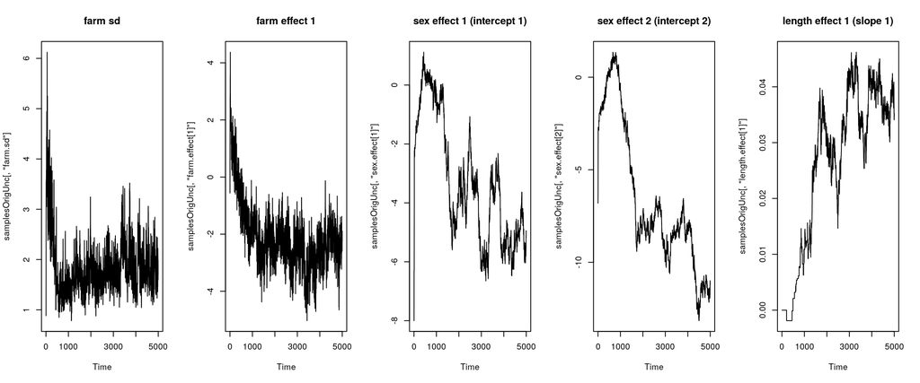

```r
par(mfrow = c(1,5))
ts.plot(samplesOrigUnc[ , 'farm.sd'], main = 'farm sd')
ts.plot(samplesOrigUnc[ , 'farm.effect[1]'], main = 'farm effect 1')
ts.plot(samplesOrigUnc[ , 'sex.effect[1]'], main = 'sex effect 1 (intercept 1)')
ts.plot(samplesOrigUnc[ , 'sex.effect[2]'], main = 'sex effect 2 (intercept 2)')
ts.plot(samplesOrigUnc[ , 'length.effect[1]'], main = 'length effect 1 (slope 1)')
```

So here the main issue is the correlation of the {intercept,slope} pairs.

# Blocking

The standard answer for that problem is to block the parameters.

After some trial and error, it turns out that modifying the defaults for the block sampler helps a huge amount and turns it from performing poorly to performing very well. One aspect of this is getting the relative scales of the parameters about right.

```r
model5 = nimbleModel(DEcode1, constants = DEconstants_uncentered, inits = DEinits_vals_uncentered, data = DEdata)
```

```
## defining model...
```

```
## building model...
```

```
## setting data and initial values...
```

```
## running calculate on model (any error reports that follow may simply reflect missing values in model variables) ...
## checking model sizes and dimensions...
## model building finished.
```

```r
cmodel5 <- compileNimble(model5)
```

```
## compiling... this may take a minute. Use 'showCompilerOutput = TRUE' to see C++ compilation details.
## compilation finished.
```

```r
mcmcConf5 <- configureMCMC(model5)
```

```
## ===== Monitors =====
## thin = 1: sex.effect, length.effect, farm.sd
## ===== Samplers =====
## RW sampler (29)
##   - sex.effect[]  (2 elements)
##   - length.effect[]  (2 elements)
##   - farm.sd
##   - farm.effect[]  (24 elements)
```

```r
mcmcConf5$removeSamplers(c('sex.effect','length.effect'))

# Add RW_block samplers, modifying adaptation behavior.
mcmcConf5$addSampler(target = c('sex.effect[1]', 'length.effect[1]'),
                 type = "RW_block",
                 control = list(propCov = diag(c(.1, .01)), adaptInterval = 20,
                                adaptFactorExponent = 0.25))
```

```
## Note: Assigning an RW_block sampler to nodes with very different scales can result in low MCMC efficiency.  If all nodes assigned to RW_block are not on a similar scale, we recommend providing an informed value for the "propCov" control list argument, or using the AFSS sampler instead.
```

```r
mcmcConf5$addSampler(target = c('sex.effect[2]', 'length.effect[2]'),
                 type = "RW_block",
                 control = list(propCov = diag(c(.1, .01)), adaptInterval = 20,
                                adaptFactorExponent = 0.25))
```

```
## Note: Assigning an RW_block sampler to nodes with very different scales can result in low MCMC efficiency.  If all nodes assigned to RW_block are not on a similar scale, we recommend providing an informed value for the "propCov" control list argument, or using the AFSS sampler instead.
```

```r
mcmcConf5$addMonitors('farm.effect')
```

```
## thin = 1: sex.effect, length.effect, farm.sd, farm.effect
```

```r
mcmc5 <- buildMCMC(mcmcConf5)
cmcmc5 <- compileNimble(mcmc5, project = model5)
```

```
## compiling... this may take a minute. Use 'showCompilerOutput = TRUE' to see C++ compilation details.
## compilation finished.
```

```r
system.time(samplesBlock <- runMCMC(cmcmc5, niter = 5000))
```

```
## running chain 1...
```

```
## |-------------|-------------|-------------|-------------|
## |-------------------------------------------------------|
```

```
##    user  system elapsed
##   2.463   0.000   2.463
```

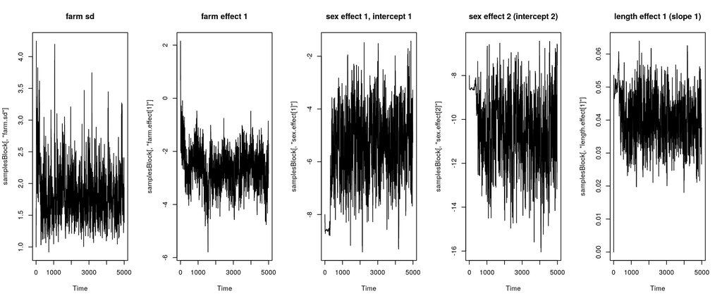

```r
par(mfrow = c(1,5))
ts.plot(samplesBlock[ , 'farm.sd'], main = 'farm sd')
ts.plot(samplesBlock[ , 'farm.effect[1]'], main = 'farm effect 1')
ts.plot(samplesBlock[ , 'sex.effect[1]'], main = 'sex effect 1, intercept 1')
ts.plot(samplesBlock[ , 'sex.effect[2]'], main = 'sex effect 2 (intercept 2)')
ts.plot(samplesBlock[ , 'length.effect[1]'], main = 'length effect 1 (slope 1)')
```

# Full comparison, accounting for sampling time

We’ll compare the uncentered approaches as in the previous module, using `compareMCMCs`. Without some additional work, we can’t compare to the centered random effects approach because the parameters are not identical (note we added `mu`).

### Make `nimbleMCMCdefs`

```r
nimbleMCMCdefs = list(
  nimble_RWblock = function(model) { # Input should be a model
    mcmcConf <- configureMCMC(model)
    mcmcConf$removeSamplers(c('sex.effect','length.effect'))
    mcmcConf$addSampler(target = c('sex.effect[1]', 'length.effect[1]'),
                        type = "RW_block",
                        control = list(propCov = diag(c(.1, .01)), adaptInterval = 20,
                                       adaptFactorExponent = 0.25))
    mcmcConf$addSampler(target = c('sex.effect[2]', 'length.effect[2]'),
                        type = "RW_block",
                        control = list(propCov = diag(c(.1, .01)), adaptInterval = 20,
                                       adaptFactorExponent = 0.25))
    mcmcConf                         # Output should be an MCMC configuration
  },
  nimble_AFSSblock = function(model) {
    mcmcConf <- configureMCMC(model)
    mcmcConf$removeSamplers(c('sex.effect','length.effect'))
    mcmcConf$addSampler(target = c('sex.effect[1]', 'length.effect[1]'),
                        type = "AF_slice",
                        control = list(sliceAdaptFactorInterval = 20))
    mcmcConf$addSampler(target = c('sex.effect[2]', 'length.effect[2]'),
                        type = "AF_slice",
                        control = list(sliceAdaptFactorInterval = 20))
    mcmcConf                         # Output should be an MCMC configuration
  }
)
```

### Call `compareMCMCs` for nimble cases (centered and uncentered)

```r
mcmcResults_nimble_centered_reparam <- compareMCMCs(
  modelInfo = list(code = DEcode3,
                   data = DEdata,
                   constants = DEconstants,
                   inits = c(DEinits_vals, list(mu = 0))),
  ## monitors ## Use default monitors: top-level parameters
  MCMCs = c('nimble',
            'nimble_slice'),
  MCMCcontrol = list(niter = 50000, burnin = 5000)
)
```

```
## building nimble model...
```

```
## defining model...
```

```
## building model...
```

```
## setting data and initial values...
```

```
## running calculate on model (any error reports that follow may simply reflect missing values in model variables) ...
## checking model sizes and dimensions...
## model building finished.
```

```
## ===== Monitors =====
## thin = 1: sex.effect, length.effect, farm.sd, mu
## ===== Samplers =====
## RW sampler (28)
##   - sex.effect[]  (1 element)
##   - length.effect[]  (2 elements)
##   - farm.sd
##   - farm.effect[]  (24 elements)
## conjugate sampler (1)
##   - mu
## ===== Monitors =====
## thin = 1: sex.effect, length.effect, farm.sd, mu
## ===== Samplers =====
## slice sampler (29)
##   - sex.effect[]  (1 element)
##   - length.effect[]  (2 elements)
##   - farm.sd
##   - mu
##   - farm.effect[]  (24 elements)
```

```
## compiling... this may take a minute. Use 'showCompilerOutput = TRUE' to see C++ compilation details.
## compilation finished.
## compiling... this may take a minute. Use 'showCompilerOutput = TRUE' to see C++ compilation details.
## compilation finished.
```

```
## |-------------|-------------|-------------|-------------|
## |-------------------------------------------------------|
## |-------------|-------------|-------------|-------------|
## |-------------------------------------------------------|
```

```r
mcmcResults_nimble_uncentered <- compareMCMCs(
  modelInfo = list(code = DEcode1,
                   data = DEdata,
                   constants = DEconstants_uncentered,
                   inits = DEinits_vals_uncentered),
  ## monitors ## Use default monitors: top-level parameters
  MCMCs = c('nimble',
            'nimble_slice',
            'nimble_RWblock',    # Name matches nimbleMCMCdefs list name
            'nimble_AFSSblock'), # Ditto
  nimbleMCMCdefs = nimbleMCMCdefs,
  MCMCcontrol = list(niter = 50000, burnin = 5000)
)
```

```
## building nimble model...
## defining model...
## building model...
## setting data and initial values...
## running calculate on model (any error reports that follow may simply reflect missing values in model variables) ...
## checking model sizes and dimensions...
## model building finished.
```

```
## ===== Monitors =====
## thin = 1: sex.effect, length.effect, farm.sd
## ===== Samplers =====
## RW sampler (29)
##   - sex.effect[]  (2 elements)
##   - length.effect[]  (2 elements)
##   - farm.sd
##   - farm.effect[]  (24 elements)
## ===== Monitors =====
## thin = 1: sex.effect, length.effect, farm.sd
## ===== Samplers =====
## slice sampler (29)
##   - sex.effect[]  (2 elements)
##   - length.effect[]  (2 elements)
##   - farm.sd
##   - farm.effect[]  (24 elements)
## ===== Monitors =====
## thin = 1: sex.effect, length.effect, farm.sd
## ===== Samplers =====
## RW sampler (29)
##   - sex.effect[]  (2 elements)
##   - length.effect[]  (2 elements)
##   - farm.sd
##   - farm.effect[]  (24 elements)
```

```
## Note: Assigning an RW_block sampler to nodes with very different scales can result in low MCMC efficiency.  If all nodes assigned to RW_block are not on a similar scale, we recommend providing an informed value for the "propCov" control list argument, or using the AFSS sampler instead.
## Note: Assigning an RW_block sampler to nodes with very different scales can result in low MCMC efficiency.  If all nodes assigned to RW_block are not on a similar scale, we recommend providing an informed value for the "propCov" control list argument, or using the AFSS sampler instead.
```

```
## ===== Monitors =====
## thin = 1: sex.effect, length.effect, farm.sd
## ===== Samplers =====
## RW sampler (29)
##   - sex.effect[]  (2 elements)
##   - length.effect[]  (2 elements)
##   - farm.sd
##   - farm.effect[]  (24 elements)
```

```
## compiling... this may take a minute. Use 'showCompilerOutput = TRUE' to see C++ compilation details.
## compilation finished.
## compiling... this may take a minute. Use 'showCompilerOutput = TRUE' to see C++ compilation details.
## compilation finished.
```

```
## |-------------|-------------|-------------|-------------|
## |-------------------------------------------------------|
## |-------------|-------------|-------------|-------------|
## |-------------------------------------------------------|
## |-------------|-------------|-------------|-------------|
## |-------------------------------------------------------|
## |-------------|-------------|-------------|-------------|
## |-------------------------------------------------------|
```

### Call `compareMCMCs` for JAGS (uncentered)

```r
mcmcResults_jags_uncentered <- compareMCMCs(
  modelInfo = list(code = DEcode2, # JAGS-compatible
                   data = list(Ecervi.01 = DeerEcervi$Ecervi.01),
                   constants = DEconstants_uncentered, # centered
                   inits = DEinits_vals_uncentered),
  ## monitors ## Use default monitors: top-level parameters
  MCMCs = c('jags'),
  MCMCcontrol = list(niter = 50000, burnin = 5000)
)
```

```
## building nimble model...
```

```
## defining model...
```

```
## building model...
```

```
## setting data and initial values...
```

```
## running calculate on model (any error reports that follow may simply reflect missing values in model variables) ...
## checking model sizes and dimensions...
## model building finished.
```

### Combine and visualize results

```r
mcmcResults_uncentered <- c(mcmcResults_nimble_uncentered,
                 mcmcResults_jags_uncentered) ## These are lists of MCMCresult objects
make_MCMC_comparison_pages(mcmcResults_uncentered, modelName = "Deer_Ecervi_uncentered_results")

make_MCMC_comparison_pages(mcmcResults_nimble_centered_reparam,
                           modelName = "Deer_Ecervi_centered_reparam_results")
```

# Think like a graph: reducing dependencies

Consider a basic state-space model.

Observation equation: $y_t \sim f(y_t | x_t)$. (Parameters are not shown.)

State equation: $x_t \sim g(x_t | x_t-1)$

Two equivalent ways to write state-space models:

1. Process-noises are random variables. States are deterministic given process noises.

```r
code_heavy <- nimbleCode({
  for(t in 1:n)
    y[t] ~ dnorm(x[t], sd = sigma)
  for(t in 2:n) {
    x[t] <- x[t-1] + eps[t-1]
    eps[t] ~ dnorm(0, sd = omega)
  }
})
```

2. States are random variables.

```r
code_light <- nimbleCode({
  for(t in 1:n)
    y[t] ~ dnorm(x[t], sd = sigma)
  for(t in 2:n)
    x[t] ~ dnorm(x[t-1], sd = omega)
})
```

# Think like a graph: reducing dependencies (2)

```r
n <- 20
m_heavy <- nimbleModel(code_heavy,
                       data = list(y = rnorm(n)),
                       constants = list(n = n))
```

```
## defining model...
```

```
## building model...
```

```
## setting data and initial values...
```

```
## running calculate on model (any error reports that follow may simply reflect missing values in model variables) ...
## checking model sizes and dimensions... This model is not fully initialized. This is not an error. To see which variables are not initialized, use model$initializeInfo(). For more information on model initialization, see help(modelInitialization).
## model building finished.
```

```r
m_light <- nimbleModel(code_light,
                       data = list(y = rnorm(n)),
                       constants = list(n = n))
```

```
## defining model...
## building model...
## setting data and initial values...
## running calculate on model (any error reports that follow may simply reflect missing values in model variables) ...
## checking model sizes and dimensions... This model is not fully initialized. This is not an error. To see which variables are not initialized, use model$initializeInfo(). For more information on model initialization, see help(modelInitialization).
## model building finished.
```

What calculations are required to update `eps[18]` or `eps[1]` compared to `x[18]` or `x[1]`?

```r
m_heavy$getDependencies('eps[18]')
```

```
## [1] "eps[18]" "x[19]"   "y[19]"   "x[20]"   "y[20]"
```

```r
m_light$getDependencies('x[18]')
```

```
## [1] "x[18]" "y[18]" "x[19]"
```

```r
m_heavy$getDependencies('eps[1]')
```

```
##  [1] "x[2]"  "y[2]"  "x[3]"  "y[3]"  "x[4]"  "y[4]"  "x[5]"  "y[5]"
##  [9] "x[6]"  "y[6]"  "x[7]"  "y[7]"  "x[8]"  "y[8]"  "x[9]"  "y[9]"
## [17] "x[10]" "y[10]" "x[11]" "y[11]" "x[12]" "y[12]" "x[13]" "y[13]"
## [25] "x[14]" "y[14]" "x[15]" "y[15]" "x[16]" "y[16]" "x[17]" "y[17]"
## [33] "x[18]" "y[18]" "x[19]" "y[19]" "x[20]" "y[20]"
```

```r
m_light$getDependencies('x[1]')
```

```
## [1] "y[1]" "x[2]"
```

# Think like a graph: when to vectorize

Vectorizing some calculations:

- Can make code more compact.
- Can make model and MCMC building and compiling faster (fewer nodes).
- Can improve MCMC efficiency, but sometimes not by much (less looping over nodes).
- Can hurt MCMC efficiency if done in the wrong places (if unneeded dependencies are introduced).

```r
code <- nimbleCode({
  intercept ~ dnorm(0, sd = 1000)
  slope ~ dnorm(0, sd = 1000)
  sigma ~ dunif(0, 100)
  predicted.y[1:4] <- intercept + slope * x[1:4] # vectorized node
  for(i in 1:4) {
    y[i] ~ dnorm(predicted.y[i], sd = sigma)
  }
})
model <- nimbleModel(code, data = list(y = rnorm(4)))
```

```
## defining model...
```

```
## building model...
```

```
## setting data and initial values...
```

```
## running calculate on model (any error reports that follow may simply reflect missing values in model variables) ...
## checking model sizes and dimensions... This model is not fully initialized. This is not an error. To see which variables are not initialized, use model$initializeInfo(). For more information on model initialization, see help(modelInitialization).
## model building finished.
```

```r
model$getDependencies('slope')
```

```
## [1] "slope"            "predicted.y[1:4]" "y[1]"
## [4] "y[2]"             "y[3]"             "y[4]"
```

Here sampling of `slope` (and `intercept`) will probably be a bit more efficient because of the vectorized definition of `predicted.y`, since all observations depend on `slope` (and `intercept`).

We avoid some overhead by having one `predicted.y[1:4]` node rather than four `predicted.y[1], ..., predicted.y[4]` nodes.

Another (manual) step would be to create a user-defined vectorized `dnorm` distribution so `y[1:4]` is a vector node.

# Think like a graph: when not to vectorize

However, if `x[2]` (and the other ’x’s) were a scalar parameter (in this case a random effect), vectorization is likely a bad idea. Any update for `x[2]` will calculate `predicted.y[1:4]` and `y[1],...,y[4]` when only `predicted.y[2]` and `y[2]` need to be calculated.

```r
code <- nimbleCode({
  intercept ~ dnorm(0, sd = 1000)
  slope ~ dnorm(0, sd = 1000)
  sigma ~ dunif(0, 100)
  predicted.y[1:4] <- intercept + slope * x[1:4] # vectorized node
  for(i in 1:4) {
    x[i] ~ dnorm(0, 1)   # scalar random effects
    y[i] ~ dnorm(predicted.y[i], sd = sigma)
  }
})
model <- nimbleModel(code, data = list(y = rnorm(4)))
```

```
## defining model...
```

```
## building model...
```

```
## setting data and initial values...
```

```
## running calculate on model (any error reports that follow may simply reflect missing values in model variables) ...
## checking model sizes and dimensions... This model is not fully initialized. This is not an error. To see which variables are not initialized, use model$initializeInfo(). For more information on model initialization, see help(modelInitialization).
## model building finished.
```

```r
model$getDependencies('x[2]')
```

```
## [1] "x[2]"             "predicted.y[1:4]" "y[1]"
## [4] "y[2]"             "y[3]"             "y[4]"
```

In this case, vectorization has made more dependencies for `x[2]` than should be necessary. This would result in wasted computation during MCMC sampling.

# Marginalization

In a hierarchical model, one can *in principle* always integrate over latent states. However only under certain situations can one do those integrals in closed form (analytically).

Analytic integration is always possible in conjugate situations. For example:

$$y_i \sim N(\mu_i, \sigma^2); i=1,\ldots,n$$
$$\mu_i \sim N(\mu_0, \sigma_0^2), i=1,\ldots,n$$

Here there is one latent state per observation. We can do MCMC here, but it involves a large number of parameters, n+3.

If we marginalize:

- We reduce the total number of computations done at each step of the MCMC.
- We reduce the dimensionality of the parameter space needing exploration.
- In some cases the complexity of calculating the marginalized density offsets some of the benefits above.

Here’s the marginalized result, with only 3 parameters.

$$y_i \sim N(\mu_0, \sigma^2 + \sigma_0^2)$$

(If we want inference on $\mu_i, i=1,\ldots,n$ we need to sample the latent states conditional on the data and the MCMC draws of $\mu_0, \sigma_0^2, \sigma^2$.)

# Generalizing the Deer example

Suppose we wanted more flexibility than assuming a normal distribution for the farm effects in the Deer example.

We could use a two-component normal mixture. In BUGS/JAGS, a standard way to do this is to introduce a latent indicator for each farm indicating which component it is in.

It would be hard to constrain the mixture to have mean zero, so we’ll move the intercept for sex 1 into the mixture.

```r
DEcodeFlex <- nimbleCode({
  for(i in 1:2) {
    # Priors for intercepts and length coefficients for sex = 1,2
    sex.effect[1] <- 0    # constraint to allow mixture to have non-zero mean
    sex.effect[2] ~ dnorm(0, sd = 1000)
    length.effect[i] ~ dnorm(0, sd = 1000)
  }

  # Priors for farm random effects
  # 'Manual' inclusion of bivariate normal mixture
  for(i in 1:num.farms) {
    farm.effect[i] ~ dnorm(mu[ind[i]+1], sd = sigma[ind[i]+1])
    ind[i] ~ dbern(pi)
  }
  for(i in 1:2) {
    mu[i] ~ dnorm(0, sd = 1000)
    sigma[i] ~ dunif(0, 20)
  }
  pi ~ dbeta(1, 1)   # same as dunif(0,1) but conjugacy will be detected

  # logit link and Bernoulli data probabilities
  for(i in 1:num.animals) {
    logit(disease.probability[i]) <-
      sex.effect[ sex[i] ] +
      length.effect[ sex[i] ]*cLength[i] +
      farm.effect[ farm.ids[i] ]
    Ecervi.01[i] ~ dbern(disease.probability[i])
  }
})
```

Note: here `ind[i]` is a non-constant index (unlike its use earlier). It’s a latent state, subject to MCMC sampling.

# Mixture models: identifiability

In mixture models, the meaning of the components can change - we could have:

$$\pi = 0.4$$
$$\mu_1 = -2, \sigma_1 = 1$$
$$\mu_2 = 1, \sigma_2 = 3$$

or

$$\pi = 0.6$$
$$\mu_1 = 1, \sigma_1 = 3$$
$$\mu_2 = -2, \sigma_2 = 1$$

This is fine if we don’t care about interpretability (though it makes assessing MCMC mixing difficult).

We could also add a constraint (which will in this case remove conjugacy) to the model code:

```
constrain_means ~ dconstraint(mu[1] < mu[2])
```

Then we would include `constrain_means = 1` in the `data` list.

# Marginalization in the Deer example

We can always integrate over finite discrete random variables by summation, so we can integrate over the `ind[i]` variables, which take values of 0 or 1.

The bivariate normal mixture density is:
$$\pi N(\mu_1, \sigma_1) + (1-\pi) N(\mu_2, \sigma_2)$$

In BUGS/JAGS, one needs to use the “zeros trick” with a Poisson distribution and an ‘observation’ set to 0 to incorporate a non-standard density. That requires some gymnastics and adds nodes to the model graph.

In NIMBLE, we write a user-defined distribution using a nimbleFunction. Let’s ignore the details for now and just focus on writing the density calculations.

```r
dnormmix2 <- nimbleFunction(
  run = function(x = double(0), prob = double(0),
                 mean = double(1), sd = double(1),
                 log = logical(0, default = 0)) {

    returnType(double(0))
    # generally we want to calculate probability (density) on a
    # log scale, but here that won't work.
    dens <- prob     * dnorm(x, mean[1], sd[1]) +
            (1-prob) * dnorm(x, mean[2], sd[2])
    if(log)
      return(log(dens)) else return(dens)
  })
```

# Using the new distribution

One can then immediately use the distribution in a model. NIMBLE will compile the user-defined distribution together with everything else, as if `dnormmix2` were a distribution that NIMBLE provides.

```r
DEcodeFlexMarg <- nimbleCode({
  # Priors for intercepts and length coefficients for sex = 1,2
  sex.effect[1] <- 0    # constraint to allow mixture to have non-zero mean
  sex.effect[2] ~ dnorm(0, sd = 1000)
  for(i in 1:2) {
    length.effect[i] ~ dnorm(0, sd = 1000)
  }

  # Priors for farm random effects (centered on the 'baseline' sex)
  for(i in 1:num.farms) {
    farm.effect[i] ~ dnormmix2(pi, mu[1:2], sigma[1:2])
  }
  for(i in 1:2) {
    mu[i] ~ dnorm(0, sd = 1000)
    sigma[i] ~ dunif(0, 20)
  }
  pi ~ dbeta(1, 1)

  # logit link and Bernoulli data probabilities
  for(i in 1:num.animals) {
    logit(disease.probability[i]) <-
      sex.effect[ sex[i] ] +
      length.effect[ sex[i] ]*cLength[i] +
      farm.effect[ farm.ids[i] ]
    Ecervi.01[i] ~ dbern(disease.probability[i])
  }
})
```

We can just create, compile, and use the model.

```r
DEconstants <- list(num.farms = 24,
                    num.animals = 826,
                    cLength = DeerEcervi$cLength,
                    sex = DeerEcervi$Sex,
                    farm.ids = DeerEcervi$farm.ids)
DEdata <- list(Ecervi.01 = DeerEcervi$Ecervi.01)

DEinits <- function() {
  list(sex.effect = c(0, 0),
       length.effect = c(0, 0),
       pi = runif(1),
       mu = rnorm(2),
       sigma = rep(1, 2),
       farm.effect = rnorm(24, 0, 1) )
}

set.seed(1)
model <- nimbleModel(DEcodeFlexMarg, data = DEdata, constants = DEconstants)
```

```
## defining model...
```

```
## Registering the following user-provided distributions: dnormmix2
## NIMBLE has registered dnormmix2 as a distribution based on its use in BUGS code. Note that if you make changes to the nimbleFunctions for the distribution, you must call 'deregisterDistributions' before using the distribution in BUGS code for those changes to take effect.
```

```
## building model...
```

```
## setting data and initial values...
```

```
## running calculate on model (any error reports that follow may simply reflect missing values in model variables) ...
## checking model sizes and dimensions... This model is not fully initialized. This is not an error. To see which variables are not initialized, use model$initializeInfo(). For more information on model initialization, see help(modelInitialization).
## model building finished.
```

```r
model$setInits(DEinits())

model$calculate('farm.effect')
```

```
## [1] -40.16775
```

```r
cModel <- compileNimble(model)
```

```
## compiling... this may take a minute. Use 'showCompilerOutput = TRUE' to see C++ compilation details.
## compilation finished.
```

```r
cModel$calculate('farm.effect')
```

```
## [1] -40.16775
```

# Exercise

```r
DEconstants <- list(num.farms = 24,
                    num.animals = 826,
                    cLength = DeerEcervi$cLength,
                    sex = DeerEcervi$Sex,
                    farm.ids = DeerEcervi$farm.ids)
DEdata <- list(Ecervi.01 = DeerEcervi$Ecervi.01)

DEinits <- function() {
  list(sex.effect = c(0, 0),
       length.effect = c(0, 0),
       farm.sd = 1,
       farm.effect = rnorm(24, 0, 1) )
}

set.seed(1)
model <- nimbleModel(DEcode1, data = DEdata, constants = DEconstants)
model$setInits(DEinits())
cModel <- compileNimble(model)

conf <- configureMCMC(model)
conf$addMonitors('farm.effect')
mcmc <- buildMCMC(conf)
cmcmc <- compileNimble(mcmc, project = model)
samples <- runMCMC(cmcmc, niter = 5000, nburnin = 0)
```